# Tema 3 — Manejo de bases de datos (R)

# 1 ¿Qué veremos en cada subtema?

- 3.0 Lectura de datos: cómo importar datos desde csv, excel, etc., inspeccionarlos rápidamente y fijar opciones (encoding, separadores, valores perdidos), revisar cabeceras y fechas.
- 3.1 Limpieza: detección y tratamiento de datos faltantes, duplicados, outliers; corrección de tipos (numérico, fecha, factor), normalización de texto (acentos, mayúsculas/minúsculas).
- 3.2 Codificación: creación y recodificación de variables (dummies/factores), estandarización o discretización cuando corresponda, construcción de índices simples.
- 3.3 Análisis: estadísticas descriptivas, tablas y relaciones entre variables.
- 3.4 Selección: filtrado por condiciones, columnas, subpoblaciones; muestreo simple.
- 3.5 Visualización: gráficos básicos para monitoreo (tendencias, comparaciones entre grupos).
- 3.6 Ejemplos con librerías en R: flujos reproducibles con dplyr, readr/readxl, lubridate, ggplot2, etc.

**Lectura de datos**

*Objetivo:* Saber importar datos correctamente y verificar que R ha interpretado bien tipos, encabezados y valores perdidos.

El formato importa:

- separador (, ; ,
- encoding (UTF-8),
- NA (valores especiales),
- fechas (YYYY-MM-DD).

Verificación rápida: tamaño, tipos de columnas, primeros registros, resumen.

Ejemplos

```r
# CSV (separador coma, codificación UTF-8)
library(readr)
encuesta <- read_csv("datos/encuesta_beneficiarios.csv", locale = locale(encoding = "UTF-8"))

# Excel
library(readxl)
padron <- read_excel("datos/padron_municipal.xlsx", sheet = "2024")

# JSON (por ejemplo, catálogo)
library(jsonlite)
cat_programas <- fromJSON("datos/catalogo_programas.json")
```

# 2 Limpieza

Cuando nos enfrentamos a un conjunto de datos es importante revisar los datos para eliminar posibles errores o insconsistencias:

- Faltantes (NA): ¿faltó respuesta? ¿códigos especiales? Decidir: imputar, eliminar, o dejar según análisis.
- Duplicados: filas repetidas (registro, id).
- Tipos incorrectos: números leídos como texto; fechas mal parseadas –> resultados erróneos.
- Outliers: valores extremos (errores de captura o casos reales). Documentar criterios.
- Normalizar texto: acentos, espacios, mayúsculas/minúsculas, para unir/contar bien.

**Caso de trabajo**

Supongamos los siguientes datos provenientes de una encuesta:

```r
encuesta <- data.frame(
  id = 1:12,
  sexo = c("M", "F", "F", NA, "F", "M", "M", "F", "F", "Otro", "M", "F"),
  edad = c(22, 35, NA, 29, 44, 19, 200, 61, 28, 37, 40, NA),   # 200 = outlier
  ingreso_mensual = c(4500, 8000, NA, 5200, 300000, 0, 6200, 7000, 5900, NA, 4800, 5100), # 300000 outlier
  municipio = c("León", "León", "Irapuato", "Celaya", "León", "Celaya",
                "Irapuato", "Celaya", "León", "León", "Irapuato", "Celaya"),
  fecha = c("2024-03-01","2024/03/05","2024-03-05","03-10-2024","2024-03-12",
            "2024-03-12", "2024-15-12", NA, "2024-03-20","2024-03-22","2024-03-25","2024-03-25")
)
```

**Datasets (incluidos en R)**

- USArrests: 50 estados y 4 variables de criminalidad (útil para ejemplos de NA/outliers si introducimos NA artificialmente y para escalado).
- airquality: tiene NA reales
- swiss: numérico/factores; socioeconómico clásico.

## 2.1 Faltantes (NA) y duplicados

```r
# Conteo de NA por columna
colSums(is.na(encuesta))
```

```
             id            sexo            edad ingreso_mensual       municipio
              0               1               2               2               0
          fecha
              1
```

```r
# Eliminar filas completamente vacías (si existieran)
encuesta <- encuesta[rowSums(is.na(encuesta)) < ncol(encuesta), ]

# Duplicados por id
sum(duplicated(encuesta$id))
```

```
[1] 0
```

```r
encuesta <- encuesta[!duplicated(encuesta$id), ]
```

## 2.2 Tipos y fechas

```r
library(lubridate)

# Varios formatos comunes en los datos:
# - "2024-03-01"  -> "%Y-%m-%d"
# - "2024/03/05"  -> "%Y/%m/%d"
# - "03-10-2024"  -> "%d-%m-%Y"
# - "2024-15-12"  -> "%Y-%d-%m"  (día-mes intercambiado en cadenas tipo "Y-d-m")

# Armonizar formato de fecha
encuesta$fecha_ok <- encuesta$fecha_ok <- parse_date_time(encuesta$fecha,orders=c('ymd','y/m/d','dmy','mdy','ydm'))

# Comprobar cuántas no se pudieron parsear:
sum(is.na(encuesta$fecha_ok))
```

```
[1] 1
```

```r
which(is.na(encuesta$fecha_ok))
```

```
[1] 8
```

```r
# Corregir valores imposibles a NA o revisarlos manualmente
encuesta$edad <- ifelse(encuesta$edad < 0 | encuesta$edad > 110, NA, encuesta$edad)
```

## 2.3 Outliers simples (reglas heurísticas)

En evaluación real es necesario justificar umbrales

```r
# Por ingreso: marcar outliers por percentiles (p99)
p99 <- quantile(encuesta$ingreso_mensual, 0.99, na.rm = TRUE)
encuesta$ingreso_mensual <- ifelse(encuesta$ingreso_mensual > p99, 'NA', encuesta$ingreso_mensual) # NA no, nombrar
```

## 2.4 Normalización de texto

```r
# Quitar espacios, pasar a minúsculas, quitar acentos con iconv
encuesta$mun_norm <- tolower(trimws(encuesta$municipio))
encuesta$mun_norm <- iconv(encuesta$mun_norm, from = "", to = "ASCII//TRANSLIT") # "leon" "leon" "leon" "irapuato" "celaya"
```

¿Qué hace cada función?

## 2.5 Imputación

```r
# Imputar ingreso_mensual
encuesta$ingreso_mensual <- as.numeric(encuesta$ingreso_mensual)
value_imputed <- data.frame(

                original = encuesta$ingreso_mensual,
                imputed_zero = replace(encuesta$ingreso_mensual, is.na(encuesta$ingreso_mensual), 0),
                imputed_mean = replace(encuesta$ingreso_mensual, is.na(encuesta$ingreso_mensual), mean(encuesta$ingreso_mensual, na.rm = TRUE)))
```

NAs:

```r
data("airquality")     # ozono, radiación solar, etc. en NY 1973
aq <- airquality

# 1) Faltantes
colSums(is.na(aq))         # NA por columna
```

```
  Ozone Solar.R    Wind    Temp   Month     Day
     37       7       0       0       0       0
```

```r
which(is.na(aq$Ozone))     # posiciones con NA en Ozone
```

```
 [1]   5  10  25  26  27  32  33  34  35  36  37  39  42  43  45  46  52  53  54
[20]  55  56  57  58  59  60  61  65  72  75  83  84 102 103 107 115 119 150
```

```r
# 2) Eliminar filas con demasiados NA (ejemplo: si todas las numéricas están NA)
aq2 <- aq[rowSums(is.na(aq)) < ncol(aq), ]

# 3) Rellenar NA con mediana de la columna (simple; documentar!)
med_oz <- median(aq$Ozone, na.rm = TRUE)
aq$Ozone_imp <- ifelse(is.na(aq$Ozone), med_oz, aq$Ozone)
```

Duplicados:

```r
df <- data.frame(id = c(1,2,2,3), x = c(10, 20, 20, 30))
duplicated(df$id)       # TRUE en la segunda aparición
```

```
[1] FALSE FALSE  TRUE FALSE
```

```r
df_nodup <- df[!duplicated(df$id), ]
```

**Ejercicios**

1. Lee el conjunto de datos encuesta_beneficiarios_v2.
2. Cuenta NA por columna y por municipio, ¿qué variable tiene más faltantes?
3. Armoniza `fecha` y escribe cuántos registros quedaron sin fecha válida.
4. Marca outliers de `edad` con regla edad > 100 y pásalos a NA.
5. Estandariza `municipio` a minúsculas sin acentos, crea municipio_norm.
6. Imputa `ingreso_mensual` por mediana dentro de municipio_norm y compara la distribución antes/después.
7. Crea un `data.frame` con duplicados en id y elimina los registros repetidos conservando la primera aparición.
8. Con `airquality`, cuenta NA por columna y reemplaza NA en `Solar.R` por la media.
9. En `airquality`, ‘cap’ (recorta) `Ozone` al percentil 99 y compara `summary()` antes/después.

**Soluciones**

```r
# 1) Leer conjunto de datos
encuesta_v2 <- read.csv("datos/encuesta_beneficiarios_v2.csv",
                        fileEncoding = "UTF-8",
                        na.strings = c("", "NA"),
                        stringsAsFactors = FALSE)
head(encuesta_v2)
```

```
  sexo edad ingreso_mensual  municipio      fecha beneficiario
1    m   76            7780     Celaya 13/03/2024            0
2    M   45            7928      LeÓn  09/03/2024            1
3 Otro   27            5872 Guanajuato       <NA>            1
4    f   69              NA     Celaya 2024.03.02            1
5    F   57            8044     Celaya 19-03-2024            0
6 <NA>   61            6156       LEON       <NA>            0
```

```r
# 2)
## NA por columna
na_por_col <- colSums(is.na(encuesta_v2))
na_por_col
```

```
           sexo            edad ingreso_mensual       municipio           fecha
              4               4               4               0               3
   beneficiario
              0
```

```r
var_mas_NA <- names(which.max(na_por_col))
cat("Variable con más NA:", var_mas_NA, "(", max(na_por_col), "NA )\n")
```

```
Variable con más NA: sexo ( 4 NA )
```

```r
## NA por municipio (cuenta de filas con al menos 1 NA)
na_por_mpio <- tapply(rowSums(is.na(encuesta_v2)) > 0, encuesta_v2$municipio, sum)
na_por_mpio
```

```
    Celaya     Celaya Guanajuato   Irapuato       LEON       León      LeÓn
         1          1          2          1          4          2          2
     Silao
         0
```

```r
# 3)
## Intentar varios formatos comunes:
## - "YYYY-MM-DD"   (2024-03-01)
## - "YYYY/MM/DD"   (2024/03/05)
## - "DD-MM-YYYY"   (03-10-2024)  -> as.Date con formato "%d-%m-%Y"
f1 <- as.Date(encuesta_v2$fecha, format = "%Y-%m-%d")
f2 <- as.Date(encuesta_v2$fecha, format = "%Y/%m/%d")
f3 <- as.Date(encuesta_v2$fecha, format = "%d-%m-%Y")

## Tomar la primera que funcione por fila
fecha_ok <- ifelse(!is.na(f1), f1,
                   ifelse(!is.na(f2), f2,
                          ifelse(!is.na(f3), f3, NA)))
encuesta_v2$fecha_ok <- as.Date(fecha_ok, origin = "1970-01-01")

## Cuántas quedaron sin fecha válida
sum(is.na(encuesta_v2$fecha_ok))
```

```
[1] 13
```

```r
which(is.na(encuesta_v2$fecha_ok))
```

```
 [1]  3  4  6 14 18 24 25 27 29 30 35 43 46
```

```r
# 4)
encuesta_v2$edad_out_na <- ifelse(!is.na(encuesta_v2$edad) & encuesta_v2$edad > 100, NA, encuesta_v2$edad)
table(is.na(encuesta_v2$edad), is.na(encuesta_v2$edad_out_na))
```

```
        FALSE TRUE
  FALSE    40    2
  TRUE      0    4
```

```r
# 5)
encuesta_v2$municipio_norm <- trimws(encuesta_v2$municipio)
encuesta_v2$municipio_norm <- tolower(encuesta_v2$municipio_norm)
encuesta_v2$municipio_norm <- iconv(encuesta_v2$municipio_norm, from = "", to = "ASCII//TRANSLIT")
encuesta_v2$municipio_norm
```

```
 [1] "celaya"     "leon"       "guanajuato" "celaya"     "celaya"
 [6] "leon"       "irapuato"   "guanajuato" "leon"       "guanajuato"
[11] "irapuato"   "celaya"     "celaya"     "irapuato"   "leon"
[16] "celaya"     "leon"       "celaya"     "leon"       "celaya"
[21] "celaya"     "leon"       "guanajuato" "irapuato"   "guanajuato"
[26] "leon"       "leon"       "irapuato"   "leon"       "leon"
[31] "celaya"     "leon"       "celaya"     "leon"       "leon"
[36] "celaya"     "guanajuato" "leon"       "leon"       "silao"
[41] "celaya"     "celaya"     "irapuato"   "celaya"     "celaya"
[46] "leon"
```

```r
# 6)
## Vector de medianas por municipio_norm (ignora NA)
medianas_por_mun <- tapply(encuesta_v2$ingreso_mensual,
                           encuesta_v2$municipio_norm,
                           median, na.rm = TRUE)

## Variable imputada
encuesta_v2$ingreso_imp <- ifelse(
  is.na(encuesta_v2$ingreso_mensual),
  medianas_por_mun[as.character(encuesta_v2$municipio_norm)],
  encuesta_v2$ingreso_mensual
)

## Comparar distribuciones
summary(encuesta_v2$ingreso_mensual)
```

```
   Min. 1st Qu.  Median    Mean 3rd Qu.    Max.    NA's
      0    5066    6240    6001    7390    8044       4
```

```r
summary(encuesta_v2$ingreso_imp)
```

```
   Min. 1st Qu.  Median    Mean 3rd Qu.    Max.
      0    5674    6340    6024    7374    8044
```

```r
# 6)

duplicated(encuesta_v2)        # marca duplicados (TRUE a partir de la 2ª aparición)
```

```
 [1] FALSE FALSE FALSE FALSE FALSE FALSE FALSE FALSE FALSE FALSE FALSE FALSE
[13] FALSE FALSE FALSE FALSE FALSE FALSE FALSE FALSE FALSE FALSE FALSE FALSE
[25] FALSE FALSE FALSE FALSE FALSE FALSE FALSE FALSE FALSE FALSE FALSE FALSE
[37] FALSE FALSE FALSE FALSE  TRUE  TRUE  TRUE  TRUE  TRUE  TRUE
```

```r
encuesta_v2_nodup <- encuesta_v2[!duplicated(encuesta_v2), ]  # conserva la primera aparición de cada obervacióm
encuesta_v2_nodup
```

```
        sexo edad ingreso_mensual  municipio      fecha beneficiario   fecha_ok
1          m   76            7780     Celaya 13/03/2024            0   13-03-20
2          M   45            7928      LeÓn  09/03/2024            1    9-03-20
3       Otro   27            5872 Guanajuato       <NA>            1       <NA>
4          f   69              NA     Celaya 2024.03.02            1       <NA>
5          F   57            8044     Celaya 19-03-2024            0   19-03-20
6       <NA>   61            6156       LEON       <NA>            0       <NA>
7          m   24            4204   Irapuato 23-03-2024            1   23-03-20
8          m   37            4460 Guanajuato 2024/04/16            1 2024-04-16
9          F   65            4845       León 08-03-2024            0    8-03-20
10  Femenino   69            7395 Guanajuato 04-01-2024            1    4-01-20
11         M   44              NA   Irapuato 2024-04-09            1 2024-04-09
12      <NA>   67            7743     Celaya 2024-04-19            1 2024-04-19
13         f   70            5731     Celaya 2024/04/07            0 2024-04-07
14      Otro   42            6785   Irapuato 2024.04.27            1       <NA>
```

[output cut: 67 more lines]

```r
# 7)
data("airquality")
aq <- airquality

colSums(is.na(aq))  # NA por columna
```

```
  Ozone Solar.R    Wind    Temp   Month     Day
     37       7       0       0       0       0
```

```r
mean_solar <- mean(aq$Solar.R, na.rm = TRUE)
aq$Solar.R_imp <- ifelse(is.na(aq$Solar.R), mean_solar, aq$Solar.R)

## Verificación
cbind(Original = colSums(is.na(airquality)),
      ConImput = colSums(is.na(aq)))
```

```
            Original ConImput
Ozone             37       37
Solar.R            7        7
Wind               0        0
Temp               0        0
Month              0        0
Day                0        0
Solar.R_imp       37        0
```

```r
summary(aq$Solar.R)
```

```
   Min. 1st Qu.  Median    Mean 3rd Qu.    Max.    NA's
    7.0   115.8   205.0   185.9   258.8   334.0       7
```

```r
summary(aq$Solar.R_imp)
```

```
   Min. 1st Qu.  Median    Mean 3rd Qu.    Max.
    7.0   120.0   194.0   185.9   256.0   334.0
```

```r
# 8)
## Crear versión imputada simple para no perder casos
oz_imp <- ifelse(is.na(aq$Ozone), median(aq$Ozone, na.rm = TRUE), aq$Ozone)

summary(aq$Ozone)   # original con NA
```

```
   Min. 1st Qu.  Median    Mean 3rd Qu.    Max.    NA's
   1.00   18.00   31.50   42.13   63.25  168.00      37
```

```r
summary(oz_imp)     # imputada por mediana
```

```
   Min. 1st Qu.  Median    Mean 3rd Qu.    Max.
   1.00   21.00   31.50   39.56   46.00  168.00
```

# 3 Codificación

Transformamos variables para análisis: recodificar categorías, crear dummies, agrupar rangos, estandarizar o construir índices sencillos:

- Recodificación: mapear categorías sueltas a valores coherentes (p. ej., “M/m/Masculino” –> “Masculino”).
- Factores: variables categóricas con niveles ordenados (útil para modelos/tablas).
- Dummies: 0/1 para usar categorías en modelos/regresiones.
- Binning: pasar continuo a rangos (cuartiles, umbrales específicos).
- Estandarizar: poner variables en escalas comparables (media 0, sd 1) para construir índices.

## 3.1 Recodificación y factores

Recodificar texto a categorías limpias:

```r
sexo_raw <- c("M", "F", "female", "Masculino", "Otro", NA, "m", "Femenino")
sexo_rec <- ifelse(sexo_raw %in% c("F","Femenino","female","f"), "Femenino",
                   ifelse(sexo_raw %in% c("M","Masculino","male","m"), "Masculino",
                          "Otro"))
sexo_fac <- factor(sexo_rec, levels = c("Femenino","Masculino","Otro"))
table(sexo_fac, useNA = "ifany")
```

```
sexo_fac
 Femenino Masculino      Otro
        3         3         2
```

## 3.2 Dummies (variables indicadoras)

```r
mujer <- as.integer(sexo_fac == "Femenino")   # 1 si Femenino, 0 si no
# También lo podríamos hacer con ifelse
```

## 3.3 Binning / categorías por rangos

```r
edad <- c(19, 25, 44, 65, 70, NA)
tramo_edad <- cut(edad,
                  breaks = c(-Inf, 29, 64, Inf),
                  labels = c("Joven","Adulto","Mayor"),
                  right = TRUE)
tramo_edad
```

```
[1] Joven  Joven  Adulto Mayor  Mayor  <NA>
Levels: Joven Adulto Mayor
```

## 3.4 Estandarización

```r
# Estandarizar ingreso_imp (media 0, sd 1)
encuesta$ingreso_z <- scale(encuesta$ingreso_mensual)[,1]
# z-score
```

## 3.5 Índice simple (combinando componentes)

Solo a modo ilustrativo, en proyectos reales es necesario justificar todas las decisiones.

```r
# Ejemplo: mayor ingreso (z) y menor edad (normalizada inversa)
# normalizar edad a [0,1] ignorando NA
rng <- range(encuesta$edad, na.rm = TRUE)
edad_norm <- (max(encuesta$edad, na.rm = TRUE) - encuesta$edad) / diff(rng)   # mayor valor = más joven
indice <- 0.7 * encuesta$ingreso_z + 0.3 * edad_norm
indice
```

```
 [1]  0.06363631  1.06278826          NA  0.23203812          NA -1.31894681
 [7]          NA  0.56507137  0.45758280          NA  0.02866566          NA
```

```r
# Un índice simple: ingreso_z y (edad invertida)
```

**Ejemplos** Con `USArrests` (criminalidad por estado)

```r
data("USArrests")
ua <- USArrests
# Crear categorías de "UrbanPop" (por terciles) y dummies (base)
cortes_u <- quantile(ua$UrbanPop, c(0, 1/3, 2/3, 1), na.rm = TRUE)
ua$UrbanCat <- cut(ua$UrbanPop, breaks = cortes_u, include.lowest = TRUE,
                   labels = c("Baja","Media","Alta"))
ua$UrbanAlta <- as.integer(ua$UrbanCat == "Alta")

# Estandarizar tasas para un índice de 'riesgo' simple
ua$Assault_z <- as.numeric(scale(ua$Assault))
ua$Murder_z  <- as.numeric(scale(ua$Murder))
ua$Rape_z    <- as.numeric(scale(ua$Rape))
ua$Riesgo    <- 0.5 * ua$Assault_z + 0.3 * ua$Murder_z + 0.2 * ua$Rape_z
head(ua)
```

```
           Murder Assault UrbanPop Rape UrbanCat UrbanAlta Assault_z   Murder_z
Alabama      13.2     236       58 21.2     Baja         0 0.7828393 1.24256408
Alaska       10.0     263       48 44.5     Baja         0 1.1068225 0.50786248
Arizona       8.1     294       80 31.0     Alta         1 1.4788032 0.07163341
Arkansas      8.8     190       50 19.5     Baja         0 0.2308680 0.23234938
California    9.0     276       91 40.6     Alta         1 1.2628144 0.27826823
Colorado      7.9     204       78 38.7     Alta         1 0.3988593 0.02571456
                 Rape_z    Riesgo
Alabama    -0.003416473 0.7635056
Alaska      2.484202941 1.2026106
Arizona     1.042878388 0.9694673
Arkansas   -0.184916602 0.1481555
California  2.067820292 1.1284517
Colorado    1.864967207 0.5801375
```

**Ejercicios**

Con el conjunto de datos swiss, que se carga del siguiente modo:

```r
data("swiss")
sw <- swiss
```

Realiza los siguientes ejercicios. No olvides que el primer paso siempre es echarle un vistazo a los datos.

1. Clasificación de Fertilidad: Clasifica la variable Fertility en cuartiles (“Q1”…“Q4”) y crea una variable FertAlta que valga 1 si el distrito está en el cuartil superior y 0 en caso contrario.
2. Índice Educativo–Examen: Estandariza Education y Examination (z-score) y crea un índice combinado $IdxEduEx = 0.5*Education_z + 0.5*Examination_z$. Examina su distribución.
3. Catolicidad en 3 grupos: Agrupa la variable Catholic en tres rangos (“Baja”, “Media”, “Alta”) y crea una variable MayorCat que valga 1 si está en el grupo “Alta” y 0 en otro caso.
4. Índice de Desventaja Infantil: Normaliza Infant.Mortality y Fertility en [0,1] (comienza creando una función que realice dicha normalización) y define $IdxDesvInf = 0.6*InfantMM + 0.4*FertMM$. Interpreta su summary().
5. Rank y Top 5 Distritos: Calcula el ranking (1 = más alto) de `IdxDesvInf` y lista los 5 distritos con valores más altos. (Pista: `order()`).
6. Cruce de variables: Cruza los cuartiles de Fertility con los 3 niveles de Catholic (CatCat) y muestra la tabla de contingencia.
7. Alta Educación y Fertilidad: Crea EduAlta = 1 si Education está en el cuartil superior y compara la media de Fertility entre EduAlta=1 y EduAlta=0.

**Soluciones**

```r
# Carga de datos
data("swiss")
sw <- swiss
head(sw)
```

```
             Fertility Agriculture Examination Education Catholic
Courtelary        80.2        17.0          15        12     9.96
Delemont          83.1        45.1           6         9    84.84
Franches-Mnt      92.5        39.7           5         5    93.40
Moutier           85.8        36.5          12         7    33.77
Neuveville        76.9        43.5          17        15     5.16
Porrentruy        76.1        35.3           9         7    90.57
             Infant.Mortality
Courtelary               22.2
Delemont                 22.2
Franches-Mnt             20.2
Moutier                  20.3
Neuveville               20.6
Porrentruy               26.6
```

```r
str(sw)         # 47 distritos x 6 variables numéricas
```

```
'data.frame':   47 obs. of  6 variables:
 $ Fertility       : num  80.2 83.1 92.5 85.8 76.9 76.1 83.8 92.4 82.4 82.9 ...
 $ Agriculture     : num  17 45.1 39.7 36.5 43.5 35.3 70.2 67.8 53.3 45.2 ...
 $ Examination     : int  15 6 5 12 17 9 16 14 12 16 ...
 $ Education       : int  12 9 5 7 15 7 7 8 7 13 ...
 $ Catholic        : num  9.96 84.84 93.4 33.77 5.16 ...
 $ Infant.Mortality: num  22.2 22.2 20.2 20.3 20.6 26.6 23.6 24.9 21 24.4 ...
```

```r
# Variables: Fertility, Agriculture, Examination, Education, Catholic, Infant.Mortality

# 1)
cortes_f <- quantile(sw$Fertility, probs = c(0,0.25,0.5,0.75,1), na.rm = TRUE)
sw$Fert_quart <- cut(sw$Fertility, breaks = cortes_f, include.lowest = TRUE,
                     labels = c("Q1","Q2","Q3","Q4"), ordered_result = TRUE)
sw$FertAlta <- as.integer(sw$Fert_quart == "Q4")
table(sw$Fert_quart)
```

```
Q1 Q2 Q3 Q4
12 12 11 12
```

```r
head(sw[, c("Fertility","Fert_quart","FertAlta")])
```

```
             Fertility Fert_quart FertAlta
Courtelary        80.2         Q4        1
Delemont          83.1         Q4        1
Franches-Mnt      92.5         Q4        1
Moutier           85.8         Q4        1
Neuveville        76.9         Q3        0
Porrentruy        76.1         Q3        0
```

```r
# 2)
sw$Education_z <- as.numeric(scale(sw$Education))
sw$Examination_z <- as.numeric(scale(sw$Examination))
sw$IdxEduEx <- 0.5*sw$Education_z + 0.5*sw$Examination_z
summary(sw$IdxEduEx)
```

```
   Min. 1st Qu.  Median    Mean 3rd Qu.    Max.
-1.3123 -0.5556 -0.1229  0.0000  0.3311  3.4706
```

```r
# 3)
sw$CatCat <- cut(sw$Catholic,
                 breaks = c(-Inf, 33.3, 66.6, Inf),
                 labels = c("Baja","Media","Alta"),
                 right = TRUE)
sw$MayorCat <- as.integer(sw$CatCat == "Alta")
table(sw$CatCat)
```

```
 Baja Media  Alta
   27     4    16
```

```r
head(sw[, c("Catholic","CatCat","MayorCat")])
```

```
             Catholic CatCat MayorCat
Courtelary       9.96   Baja        0
Delemont        84.84   Alta        1
Franches-Mnt    93.40   Alta        1
Moutier         33.77  Media        0
Neuveville       5.16   Baja        0
Porrentruy      90.57   Alta        1
```

```r
# 4)
norm_minmax <- function(v) (v - min(v, na.rm=TRUE)) / diff(range(v, na.rm=TRUE))
InfantMM <- norm_minmax(sw$Infant.Mortality)
FertMM   <- norm_minmax(sw$Fertility)
sw$IdxDesvInf <- 0.6*InfantMM + 0.4*FertMM
summary(sw$IdxDesvInf)
```

```
   Min. 1st Qu.  Median    Mean 3rd Qu.    Max.
 0.1343  0.4934  0.5854  0.5917  0.6778  0.9347
```

```r
# Justificación: mayor peso a mortalidad infantil por su gravedad en políticas de salud.


# 5)
ord <- order(sw$IdxDesvInf, decreasing = TRUE)
top5 <- ord[1:5]
sw[top5, c("Fertility","Infant.Mortality","IdxDesvInf")]
```

```
           Fertility Infant.Mortality IdxDesvInf
Glane           92.4             24.9  0.9347474
Porrentruy      76.1             26.6  0.8859130
Veveyse         87.1             24.5  0.8826879
Sarine          82.9             24.4  0.8496731
Broye           83.8             23.6  0.8255542
```

```r
# 6)
tab <- table(sw$Fert_quart, sw$CatCat)
tab
```

```
     Baja Media Alta
  Q1    9     3    0
  Q2   10     0    2
  Q3    7     0    4
  Q4    1     1   10
```

```r
prop.table(tab, margin = 2)   # proporciones por columna (opcional)
```

```
           Baja      Media       Alta
  Q1 0.33333333 0.75000000 0.00000000
  Q2 0.37037037 0.00000000 0.12500000
  Q3 0.25925926 0.00000000 0.25000000
  Q4 0.03703704 0.25000000 0.62500000
```

```r
# 7)
cortes_ed <- quantile(sw$Education, probs = c(0,.25,.5,.75,1), na.rm = TRUE)
sw$Edu_quart <- cut(sw$Education, breaks = cortes_ed, include.lowest = TRUE,
                    labels = c("Q1","Q2","Q3","Q4"), ordered_result = TRUE)
sw$EduAlta <- as.integer(sw$Edu_quart == "Q4")

tapply(sw$Fertility, sw$EduAlta, mean, na.rm = TRUE)
```

```
       0        1
73.04722 60.63636
```

# 4 Análisis

Es el primer diagnóstico cuantitativo de un conjunto de datos: entender magnitudes, dispersiones, relaciones, y diferencias entre grupos. Antes de modelar o graficar, necesitamos saber qué hay, cómo se distribuye y dónde están los problemas (NA, atípicos, unidades, etc.).

**Objetivos:**

- Resumir variables numéricas (medias, medianas, cuartiles, rangos).
- Contar y cruzar variables categóricas (tablas de frecuencias y proporciones).
- Medir relaciones básicas (correlaciones, covarianzas).
- Comparar entre grupos (por mes, por municipio, por tramo de edad,…).

**Ideas clave (con R base):**

- Resúmenes rápidos: `summary(x)` muestra mínimo, cuartiles, mediana y máximo en el caso de variables cuantitativas, y muestra cantidad de valores por cada categoría en el caso de variables cualitativas.
- Medidas puntuales: `mean(x, na.rm=TRUE)`, `sd()`, `median()`, `quantile()`.
  - Tip: la mediana es más robusta a atípicos que la media.
- Tablas categóricas: `table(g)`, y proporciones con `prop.table(table(g))`.
  - Por margen: prop.table(tabla, margin = 1) (por fila) o margin = 2 (por columna).
- Por grupo:
  - `tapply(x, g, FUN)` → aplica `FUN` a `x` dentro de cada grupo `g`.
  - `aggregate(y ~ g1 + g2, data=df, FUN)` –> resúmenes por múltiples grupos.
- Relaciones:
  - `cor(x, y, use="complete.obs")` –> relación lineal entre variables.
  - Interpretación: valores cercano a 1 o -1 = relación lineal fuerte; cerca de 0 = débil o no lineal.
  - Ignora NAs por defecto.
- Top-N / ranking:
  - `order(x, decreasing=TRUE)` da el índice para reordenar el data frame y ver los ‘top’.
  - `which.max(x)` / `which.min(x)` señala máximos y mínimos.
- NA importan: Muchos fallos vienen de olvidar `na.rm=TRUE`. Úsalo en todas las funciones que lo admiten si hay NA.

**Ejemplos**

¿Cómo cambia el Ozono por mes?

```r
tapply(aq$Ozone, aq$Month, mean, na.rm=TRUE)
```

```
       5        6        7        8        9
23.61538 29.44444 59.11538 59.96154 31.44828
```

¿Cómo de relacionados están Murder y Assault?

```r
cor(ua$Murder, ua$Assault)
```

```
[1] 0.8018733
```

¿Cuál es el top 5 de Fertility?

```r
swiss[order(swiss$Fertility, decreasing=TRUE), ][1:5, ]
```

```
             Fertility Agriculture Examination Education Catholic
Franches-Mnt      92.5        39.7           5         5    93.40
Glane             92.4        67.8          14         8    97.16
Sierre            92.2        84.6           3         3    99.46
Veveyse           87.1        64.5          14         6    98.61
Moutier           85.8        36.5          12         7    33.77
             Infant.Mortality
Franches-Mnt             20.2
Glane                    24.9
Sierre                   16.3
Veveyse                  24.5
Moutier                  20.3
```

¿Cuáles son los 15 días con Ozone más alto?

```r
idx <- order(aq$Ozone, decreasing = TRUE, na.last = NA)[1:15]
aq[idx, c("Ozone","Solar.R","Temp","Month","Day")]
```

```
    Ozone Solar.R Temp Month Day
117   168     238   81     8  25
62    135     269   84     7   1
99    122     255   89     8   7
121   118     225   94     8  29
30    115     223   79     5  30
101   110     207   90     8   9
86    108     223   85     7  25
69     97     267   92     7   8
70     97     272   92     7   9
124    96     167   91     9   1
127    91     189   93     9   4
100    89     229   90     8   8
71     85     175   89     7  10
123    85     188   94     8  31
122    84     237   96     8  30
```

Categoriza la variable edad de encuesta_v2 y crúzala con la variable sexo.

```r
encuesta_v2$tramo_edad <- cut(encuesta_v2$edad, c(-Inf,29,64,Inf), labels = c("Joven","Adulto","Mayor"))
table(encuesta_v2$tramo_edad, encuesta_v2$sexo, useNA = "ifany")
```

```
         f F Femenino m M Masculino Otro <NA>
  Joven  1 1        1 1 0         2    3    0
  Adulto 1 6        2 2 6         0    1    1
  Mayor  2 1        3 5 0         0    0    3
  <NA>   0 1        0 0 1         1    1    0
```

```r
normalizar_texto <- function(x) {
  y <- trimws(x)
  z <- iconv(y, from = "", to = "ASCII//TRANSLIT")
  tolower(ifelse(is.na(z), y, z))
}
sexo_norm <- normalizar_texto(encuesta_v2$sexo)

fem <- c("f","femenino","female","mujer")
mas <- c("m","masculino","male","hombre")

sexo_rec <- ifelse(sexo_norm %in% fem, "Femenino",
             ifelse(sexo_norm %in% mas, "Masculino", "Otro/ND"))

encuesta_v2$sexo_rec <- factor(sexo_rec, levels = c("Femenino","Masculino","Otro/ND"))
table(encuesta_v2$tramo_edad, encuesta_v2$sexo_rec, useNA = "ifany")
```

```
         Femenino Masculino Otro/ND
  Joven         3         3       3
  Adulto        9         8       2
  Mayor         6         5       3
  <NA>          1         2       1
```

# 5 Selección

Consiste en extraer subconjuntos del data frame: filas que cumplen condiciones, columnas relevantes, ordenar, eliminar duplicados, y muestrear. Sin seleccionar bien, cualquier análisis puede mezclar peras con manzanas.

**Objetivos**

- Elegir filas por condiciones lógicas: “ingreso > 7000 y edad $\in [30,64]$”.
- Elegir columnas por nombre, posición, etc.
- Ordenar para ver top/bottom y preparar tablas.
- Obtener muestras.
- Quitar duplicados o quedarnos con “el más reciente”.

**Ideas clave (R base)**

- Filtrado de filas con corchetes: `df[condicion, ]`.
  - Combina condiciones con `&` (y), `|` (o), `!` (no). ¡Usa paréntesis para asegurar!
- Selección de columnas: `df[, c("col1","col2")]` o por patrón `grep("patron", names(df))`.
- Ordenación: `df[order(df$var, decreasing=TRUE), ]`.
- Duplicados:
  - `duplicated(df$id)` marca TRUE a partir de la segunda vez que aparece ese id.
  - `df[!duplicated(df$id), ]` conserva la primera aparición.
- Muestreo. Simple: `df[sample.int(nrow(df), k), ]`.

**Ejemplos** Filas con Ozone > 100 y Solar.R no NA.

```r
aq[aq$Ozone > 100 & !is.na(aq$Solar.R), ]
```

```
      Ozone Solar.R Wind Temp Month Day Solar.R_imp
NA       NA      NA   NA   NA    NA  NA          NA
NA.1     NA      NA   NA   NA    NA  NA          NA
NA.2     NA      NA   NA   NA    NA  NA          NA
30      115     223  5.7   79     5  30         223
NA.3     NA      NA   NA   NA    NA  NA          NA
NA.4     NA      NA   NA   NA    NA  NA          NA
NA.5     NA      NA   NA   NA    NA  NA          NA
NA.6     NA      NA   NA   NA    NA  NA          NA
NA.7     NA      NA   NA   NA    NA  NA          NA
NA.8     NA      NA   NA   NA    NA  NA          NA
NA.9     NA      NA   NA   NA    NA  NA          NA
NA.10    NA      NA   NA   NA    NA  NA          NA
NA.11    NA      NA   NA   NA    NA  NA          NA
NA.12    NA      NA   NA   NA    NA  NA          NA
NA.13    NA      NA   NA   NA    NA  NA          NA
NA.14    NA      NA   NA   NA    NA  NA          NA
NA.15    NA      NA   NA   NA    NA  NA          NA
NA.16    NA      NA   NA   NA    NA  NA          NA
NA.17    NA      NA   NA   NA    NA  NA          NA
NA.18    NA      NA   NA   NA    NA  NA          NA
NA.19    NA      NA   NA   NA    NA  NA          NA
NA.20    NA      NA   NA   NA    NA  NA          NA
NA.21    NA      NA   NA   NA    NA  NA          NA
NA.22    NA      NA   NA   NA    NA  NA          NA
NA.23    NA      NA   NA   NA    NA  NA          NA
62      135     269  4.1   84     7   1         269
NA.24    NA      NA   NA   NA    NA  NA          NA
NA.25    NA      NA   NA   NA    NA  NA          NA
NA.26    NA      NA   NA   NA    NA  NA          NA
NA.27    NA      NA   NA   NA    NA  NA          NA
NA.28    NA      NA   NA   NA    NA  NA          NA
86      108     223  8.0   85     7  25         223
99      122     255  4.0   89     8   7         255
101     110     207  8.0   90     8   9         207
NA.29    NA      NA   NA   NA    NA  NA          NA
NA.30    NA      NA   NA   NA    NA  NA          NA
NA.31    NA      NA   NA   NA    NA  NA          NA
NA.32    NA      NA   NA   NA    NA  NA          NA
117     168     238  3.4   81     8  25         238
NA.33    NA      NA   NA   NA    NA  NA          NA
121     118     225  2.3   94     8  29         225
NA.34    NA      NA   NA   NA    NA  NA          NA
```

Columnas que contienen “a” en el nombre:

```r
aqa <- aq[, grep("a", names(aq))]
```

Top 10 Temp más altas (con su fecha)

```r
topT <- aq[order(aq$Temp, decreasing = TRUE), ][1:10, c("Temp","Month","Day")]
topT
```

```
    Temp Month Day
120   97     8  28
122   96     8  30
121   94     8  29
123   94     8  31
42    93     6  11
126   93     9   3
127   93     9   4
43    92     6  12
69    92     7   8
70    92     7   9
```

Estados con UrbanPop en Q3/Q4 y Assault > mediana

```r
ua <- USArrests
medA <- median(ua$Assault)
sel  <- ua$UrbanPop >= quantile(ua$UrbanPop, 0.5) & ua$Assault > medA
ua_sel <- rownames(ua[sel, ])
ua_sel
```

```
 [1] "Arizona"      "California"   "Colorado"     "Delaware"     "Florida"
 [6] "Illinois"     "Louisiana"    "Maryland"     "Michigan"     "Missouri"
[11] "Nevada"       "New Mexico"   "New York"     "Rhode Island" "Texas"
```

Distritos con Catholic > 66 y Fertility por encima de Q3

```r
sw <- swiss
sel <- sw$Catholic > 66 & sw$Fertility > quantile(sw$Fertility, .75)
sw_sel <- sw[sel, ]
sw_sel
```

```
             Fertility Agriculture Examination Education Catholic
Delemont          83.1        45.1           6         9    84.84
Franches-Mnt      92.5        39.7           5         5    93.40
Broye             83.8        70.2          16         7    92.85
Glane             92.4        67.8          14         8    97.16
Gruyere           82.4        53.3          12         7    97.67
Sarine            82.9        45.2          16        13    91.38
Veveyse           87.1        64.5          14         6    98.61
Monthey           79.4        64.9           7         3    98.22
Sierre            92.2        84.6           3         3    99.46
Sion              79.3        63.1          13        13    96.83
             Infant.Mortality
Delemont                 22.2
Franches-Mnt             20.2
Broye                    23.6
Glane                    24.9
Gruyere                  21.0
Sarine                   24.4
Veveyse                  24.5
Monthey                  20.2
Sierre                   16.3
Sion                     18.1
```

Subpoblación: beneficiarios con ingreso > 7000 y edad 30–64

```r
encuesta_v2 <- read.csv("datos/encuesta_beneficiarios_v2.csv")

sub_ben <- subset(encuesta_v2, beneficiario == 1 & ingreso_mensual > 7000 & edad >= 30 & edad <= 64)
sub_ben
```

```
       sexo edad ingreso_mensual municipio      fecha beneficiario
2         M   45            7928     LeÓn  09/03/2024            1
22        M   30            7377      León 2024-03-15            1
35 Femenino   49            7220      LEON 2024.04.09            1
46 Femenino   49            7220      LEON 2024.04.09            1
```

Con los datos swiss, categoriza la variable Catholic. Después, para cada categoría, calcula la correlación Fertility ~ Education.

```r
data("swiss")
sw <- swiss

med_cat <- median(sw$Catholic, na.rm = TRUE)
grupo <- ifelse(sw$Catholic <= med_cat, "Baja", "Alta")

# Correlaciones por grupo
c_baja <- cor(sw$Fertility[grupo=="Baja"], sw$Education[grupo=="Baja"])
c_alta <- cor(sw$Fertility[grupo=="Alta"],        sw$Education[grupo=="Alta"])
c_baja
```

```
[1] -0.3396416
```

```r
c_alta
```

```
[1] -0.8004069
```

Summary de Infant.Mortality cuando la fertilidad es mayor que su cuartil q4 y la educación está en su cuartil Q1.

```r
sw <- swiss

# Cuartiles
qF <- quantile(sw$Fertility, c(0,.25,.5,.75,1), na.rm = TRUE)
qE <- quantile(sw$Education, c(0,.25,.5,.75,1), na.rm = TRUE)

sel <- sw$Fertility >= qF[4] & sw$Education <= qE[2]  # Q4 Fertility y Q1 Education
summary(sw[sel, 'Infant.Mortality'])
```

```
   Min. 1st Qu.  Median    Mean 3rd Qu.    Max.
  16.30   19.23   20.20   20.30   21.27   24.50
```

# 6 Visualización

Un gráfico debe responder una pregunta. Debemos, por tanto, escoger el tipo de gráfico según el tipo de variable y la comparación deseada.

Algunos gráficos clásicos son:

- Categórica –> Frecuencias: `barplot()` (barras).
- Numérica –> Distribución: `hist()` (histograma), `boxplot()` (caja y bigotes).
- Numérica vs numérica –> Relación: `plot()` (dispersión), con `abline()` para tendencias simples.
- Grupos: barras agrupadas (`barplot(..., beside=TRUE)`), boxplots por grupo (`boxplot(y ~ g)`).

Algunas personalizaciones:

- Títulos y ejes: `main=`, `xlab=`, `ylab=`.
- Rango de ejes: `xlim=`, `ylim=`.
- Simbología: `pch` (forma del punto), `cex` (tamaño), `lwd` (grosor), `lty` (tipo de línea).
- Colores básicos: `col=` (usa nombres ‘red’, ‘steelblue’, etc., o índices).
- Leyendas: `legend("topleft", legend=, col=, pch=, lwd=)`.

Otras opciones interesantes:

- Multipanel: `par(mfrow=c(filas, cols))` para poner varios gráficos en una misma ventana (recuerda devolver luego par(op)).
- Guardar imágenes: `png("archivo.png", width=1200, height=800, res=150)`.

## 6.1 Ejemplos

### 6.1.1 Barras

**Frecuencias simples**

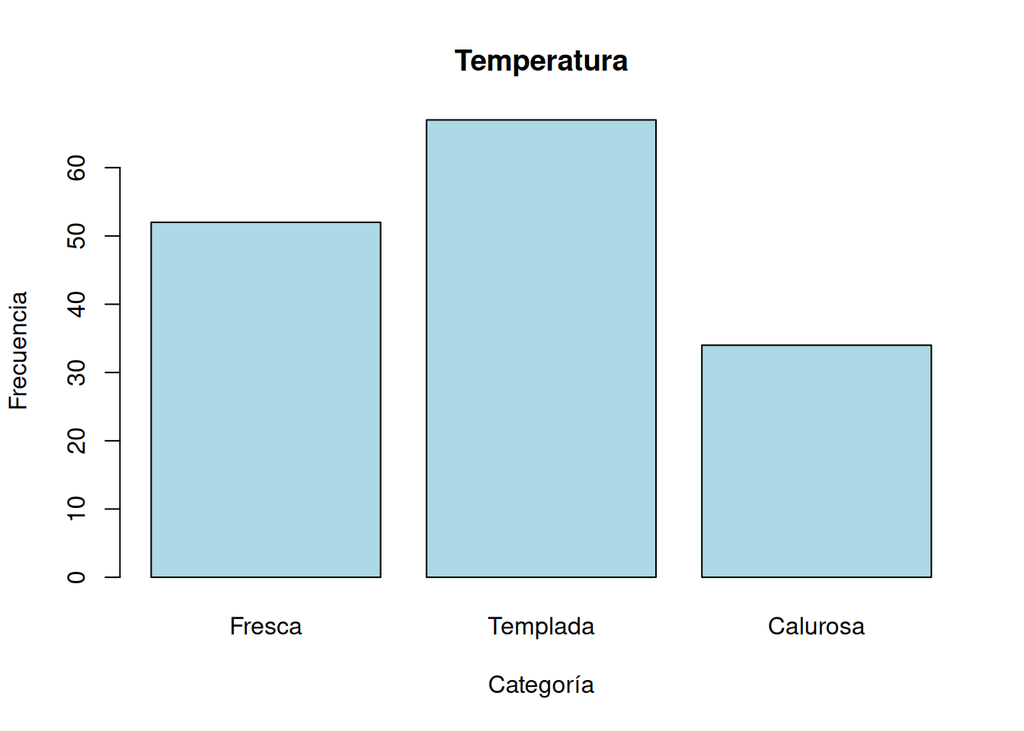

```r
# Categorizamos Temp en airquality
aq$Temp_cat <- cut(aq$Temp, breaks = c(-Inf, 75, 85, Inf),
                   labels = c("Fresca","Templada","Calurosa"))
freq <- table(aq$Temp_cat)

barplot(freq,
        main = "Temperatura",
        xlab = "Categoría", ylab = "Frecuencia",
        col = "lightblue")
```

**Barras agrupadas/apiladas**

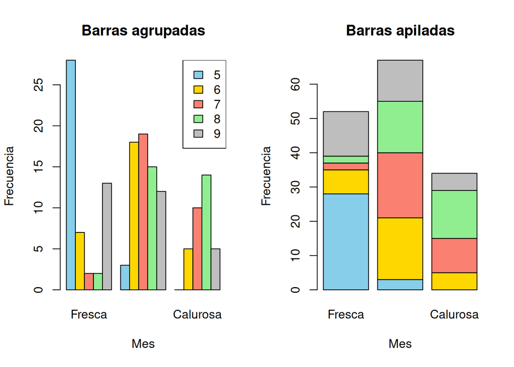

```r
aq$Month <- as.factor(aq$Month)
# Cruce Mes × Categoría de Temp
tab <- table(aq$Month, aq$Temp_cat)

par(mfrow = c(1, 2))
barplot(tab, beside = TRUE,
        main = "Barras agrupadas",
        xlab = "Mes", ylab = "Frecuencia",
        col = c("skyblue","gold","salmon","lightgreen",'gray'))
legend("topright", legend = rownames(tab),
       fill = c("skyblue","gold","salmon","lightgreen",'gray'))

barplot(tab, beside = FALSE,
        main = "Barras apiladas",
        xlab = "Mes", ylab = "Frecuencia",
        col = c("skyblue","gold","salmon","lightgreen",'gray'))
```

```r
par(mfrow = c(1, 1))
```

### 6.1.2 Dispersión/línea

**Relación de dos variables numéricas**

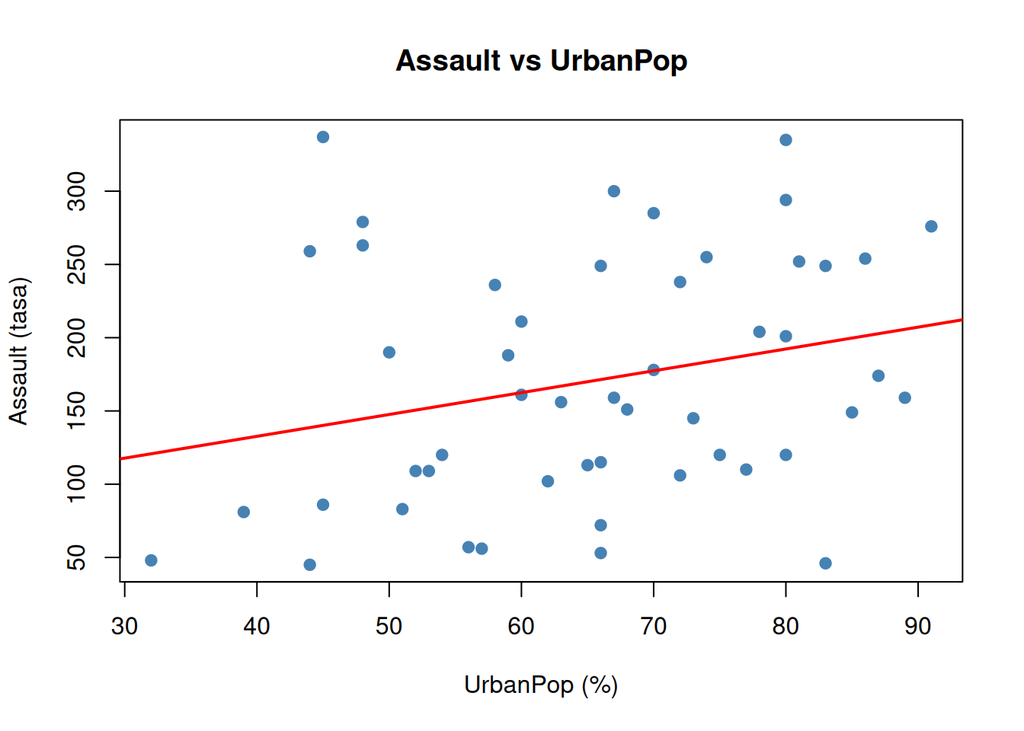

```r
# USArrests: Assault vs. UrbanPop
plot(ua$UrbanPop, ua$Assault,
     main = "Assault vs UrbanPop",
     xlab = "UrbanPop (%)", ylab = "Assault (tasa)",
     pch = 19, col = "steelblue")

# Recta de regresión (mínimos cuadrados)
mod <- lm(Assault ~ UrbanPop, data = ua)
abline(mod, col = "red", lwd = 2)
```

**Serie simple con línea**

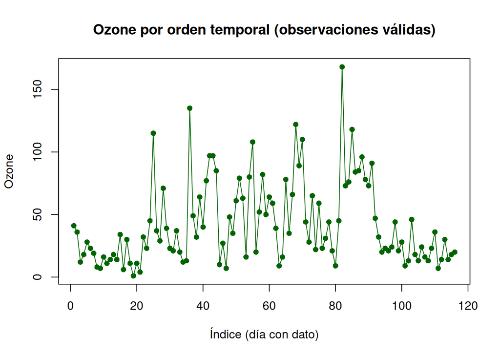

```r
# airquality: Ozone a lo largo de los días (filtramos NA)
ok <- complete.cases(aq$Ozone)
plot(aq$Ozone[ok], type = "o",
     main = "Ozone por orden temporal (observaciones válidas)",
     xlab = "Índice (día con dato)", ylab = "Ozone",
     pch = 16, col = "darkgreen")
```

**Varias series a la vez**

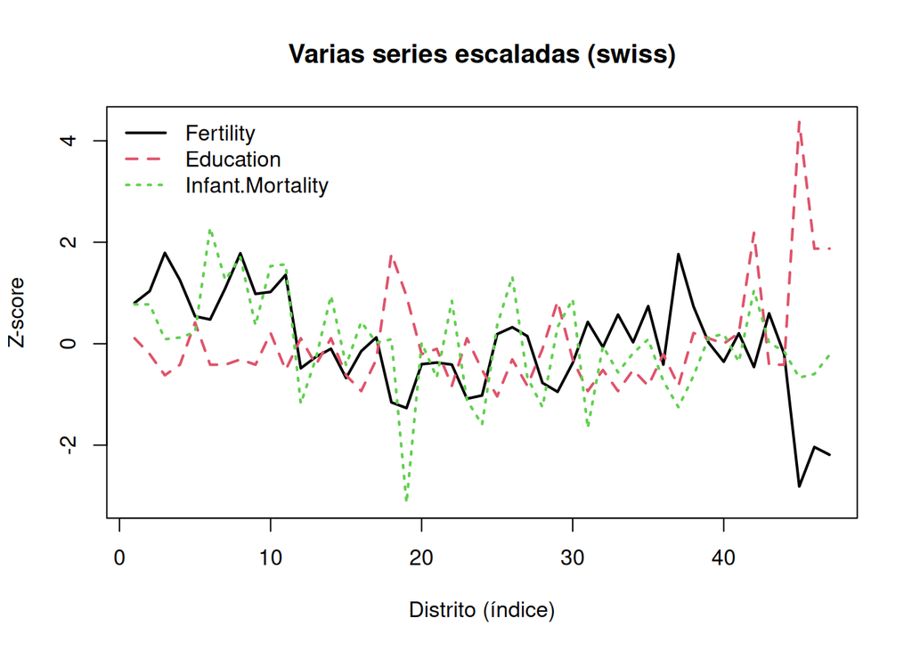

```r
# swiss: dibujamos varias columnas escaladas
S <- scale(sw[, c("Fertility","Education","Infant.Mortality")])
matplot(S, type = "l", lty = 1:3, lwd = 2,
        main = "Varias series escaladas (swiss)",
        xlab = "Distrito (índice)", ylab = "Z-score")
legend("topleft", legend = c("Fertility","Education","Infant.Mortality"),
       col = 1:3, lty = 1:3, lwd = 2, bty = "n")
```

### 6.1.3 Histogramas

**Distribución de una variable numérica**

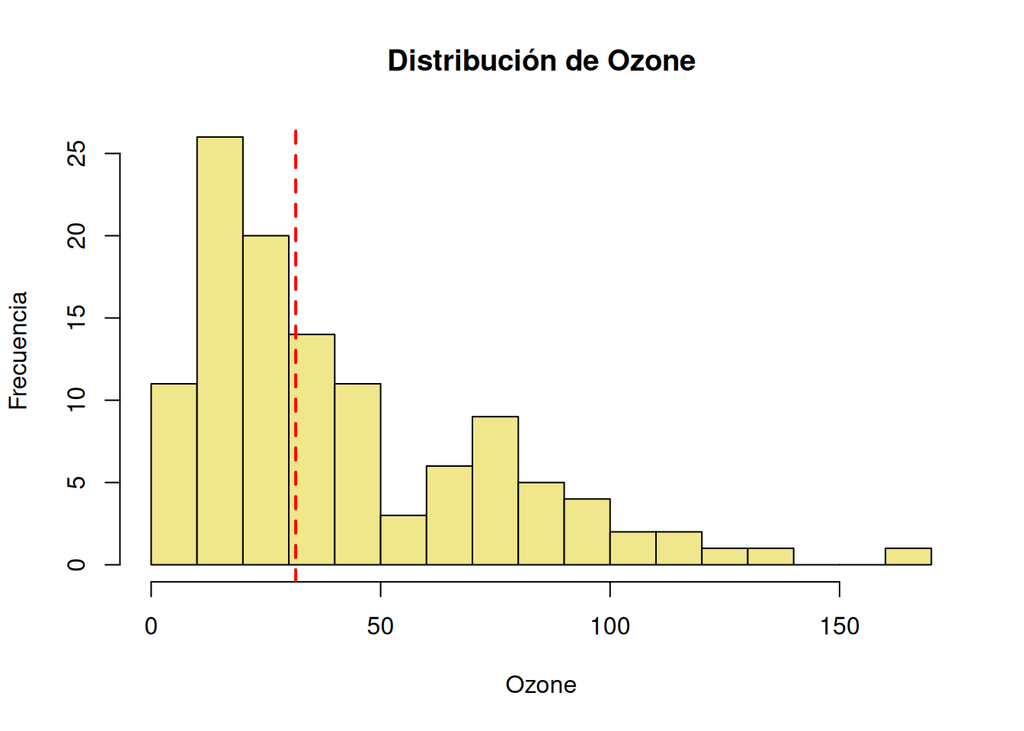

```r
hist(aq$Ozone,
     main = "Distribución de Ozone",
     xlab = "Ozone", ylab = "Frecuencia",
     col = "khaki", breaks = 12)
abline(v = median(aq$Ozone, na.rm = TRUE), col = "red", lwd = 2, lty = 2)
```

### 6.1.4 Diagrama de cajas y bigotes (boxplot)

**Una variable**

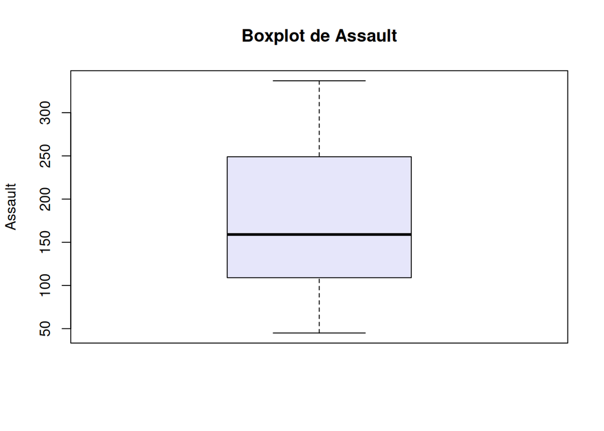

```r
boxplot(ua$Assault,
        main = "Boxplot de Assault",
        ylab = "Assault",
        col = "lavender")
```

**Por grupos**

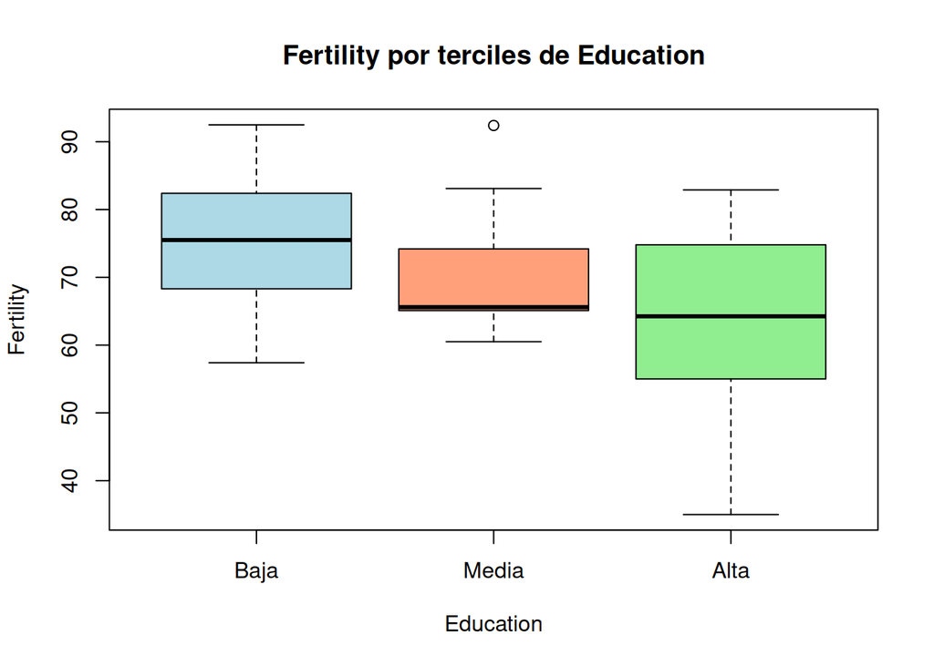

```r
# swiss: Fertility por terciles de Education
qE <- quantile(sw$Education, c(0, 1/3, 2/3, 1))
sw$Edu_terc <- cut(sw$Education, qE, include.lowest = TRUE, labels = c("Baja","Media","Alta"))

boxplot(Fertility ~ Edu_terc, data = sw,
        main = "Fertility por terciles de Education",
        xlab = "Education", ylab = "Fertility",
        col = c("lightblue","lightsalmon","lightgreen"))
```

## 6.2 Guardar archivo

```r
png("mi_grafico.png", width=1200, height=900, res=150)
plot(ua$UrbanPop, ua$Assault, main="Guardado a PNG")
dev.off()
```

La función `dev.off()` sirve para cerrar el dispositivo gráfico que hemos elegido, de este modo se creará un archivo y podremos crear más gráficos después.

**Ejercicios**

1. Calcula los 5 estados con mayor Assault y dibuja un barplot() ordenado (de mayor a menor), con eje y etiquetado y nombres de estados en el eje x (dataset USArrests).
2. Diagrama de dispersión de Temp y Ozone (dataset airquality).
3. En un panel 2×2, dibuja histogramas de Ozone para todos los meses.
4. Crea terciles de Catholic y dibuja boxplot(Fertility ~ tercil) (dataset swiss).
5. Divide UrbanPop en terciles y colorea el scatter Assault vs Murder por tercil. Añade leyenda (dataset USArrests).
6. Grafica Temp como serie (orden natural de filas) con type=“o”, y marca con líneas horizontales la media y la mediana (dataset airquality).

**Soluciones**

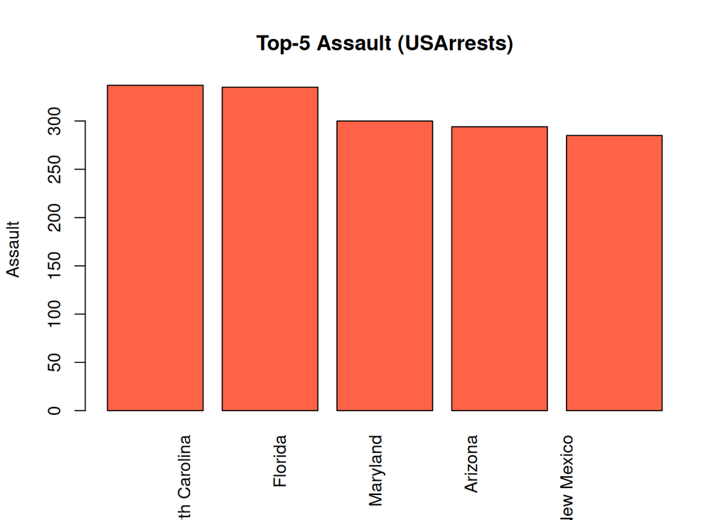

```r
# 1)
ua <- USArrests
ord <- order(ua$Assault, decreasing = TRUE)
top5 <- ua[ord[1:5], "Assault"]
barplot(top5,
        main = "Top-5 Assault (USArrests)",
        ylab = "Assault", xlab = " ",
        col = "tomato")
axis(1, at = seq_along(top5), labels = rownames(ua)[ord[1:5]], las = 2, tick = FALSE)
```

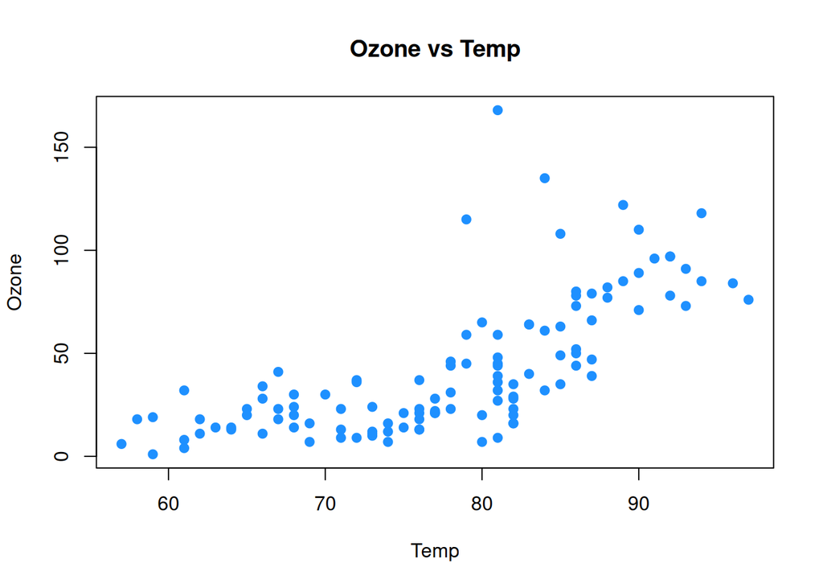

```r
# 2)
aq <- airquality
ok <- complete.cases(aq[, c("Ozone","Temp")])
plot(aq$Temp[ok], aq$Ozone[ok],
     main = "Ozone vs Temp", xlab = "Temp", ylab = "Ozone",
     pch = 19, col = "dodgerblue")
```

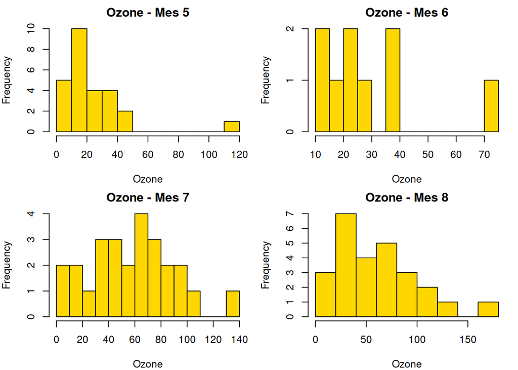

```r
# 3)
op <- par(mfrow = c(2,2), mar = c(4,4,2,1))
for (m in 5:8) {
  sel <- aq$Month == m & !is.na(aq$Ozone)
  hist(aq$Ozone[sel],
       main = paste("Ozone - Mes", m),
       xlab = "Ozone",
       col = "gold", breaks = 10)
}
```

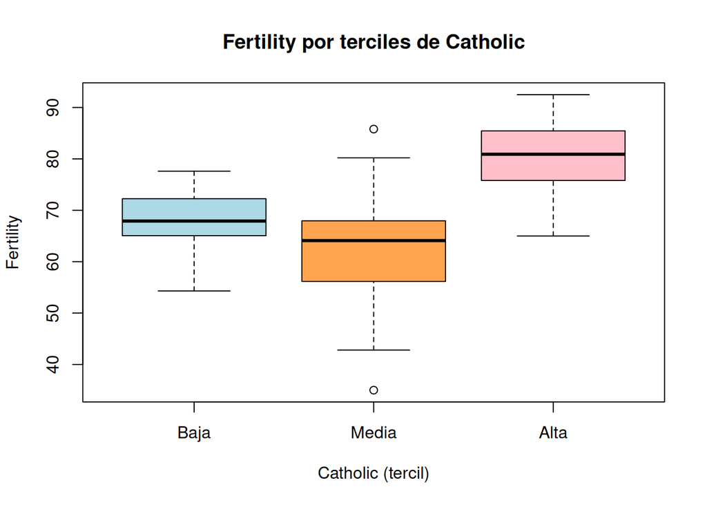

```r
par(op)

# 4)
sw <- swiss
qC <- quantile(sw$Catholic, c(0, 1/3, 2/3, 1))
sw$Cat_terc <- cut(sw$Catholic, qC, include.lowest = TRUE,
                   labels = c("Baja","Media","Alta"))
boxplot(Fertility ~ Cat_terc, data = sw,
        main = "Fertility por terciles de Catholic",
        xlab = "Catholic (tercil)", ylab = "Fertility",
        col = c("lightblue","tan1","pink"))
```

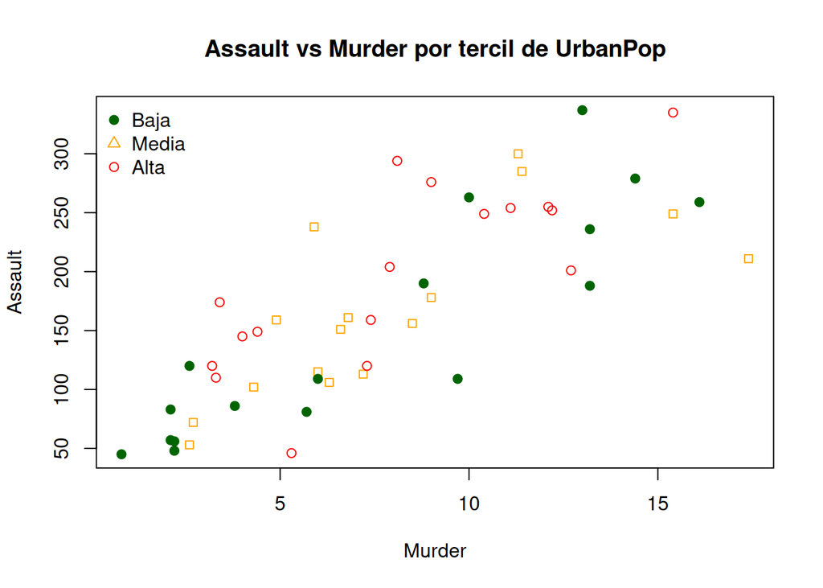

```r
# 5)
cuts <- quantile(ua$UrbanPop, c(0,1/3,2/3,1))
ua$UrbanCat <- cut(ua$UrbanPop, cuts, include.lowest = TRUE, labels = c("Baja","Media","Alta"))
cols <- c("darkgreen","orange","red")[ua$UrbanCat]
formas <- c(19,22,21)[ua$UrbanCat]

plot(ua$Murder, ua$Assault,
     main = "Assault vs Murder por tercil de UrbanPop",
     xlab = "Murder", ylab = "Assault",
     pch = formas, col = cols)
legend("topleft", legend = levels(ua$UrbanCat),
       col = c("darkgreen","orange","red"), pch = c(19,2,21), bty = "n")
```

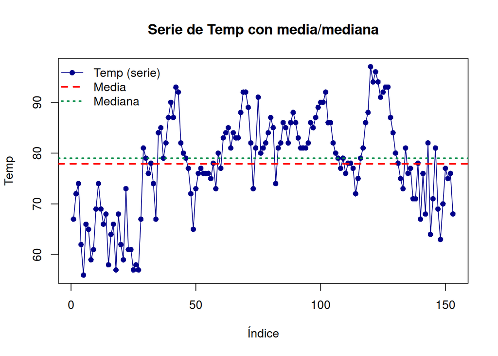

```r
# 6)
plot(aq$Temp, type = "o",
     main = "Serie de Temp con media/mediana",
     xlab = "Índice", ylab = "Temp",
     pch = 16, col = "darkblue")
abline(h = mean(aq$Temp, na.rm = TRUE), col = "red", lwd = 2, lty = 2)
abline(h = median(aq$Temp, na.rm = TRUE), col = "springgreen4", lwd = 2, lty = 3)
# Leyenda
legend("topleft",
       legend = c("Temp (serie)", "Media", "Mediana"),
       col    = c("darkblue", "red", "springgreen4"),
       lty    = c(1, 2, 3),
       lwd    = c(1, 2, 2),
       pch    = c(16, NA, NA),   # punto para la serie, sin símbolo para líneas
       pt.cex = 1,
       bty    = "n")             # sin caja
```

# 7 Ejemplos en librerías de R

Hasta ahora, nos hemos centrado principalmente en R base. No obstante, R cuenta con diversas librerías de gran utilidad para el análisis de datos. En esta sección nos centraremos en las librerías `dplyr` y `ggplot`. Iremos mostrando distintos ejemplos de las diferentes secciones abordadas en este tema.

**Carga de librerías y lectura de datos**

```r
# Instala si hace falta:
# install.packages(c("tidyverse", "palmerpenguins"))

library(dplyr)
library(ggplot2)
theme_set(theme_minimal())  # estética limpia por defecto

# Datasets base
data("airquality"); aq <- airquality
data("USArrests");  ua <- USArrests %>% tibble::rownames_to_column("state")
data("swiss");      sw <- swiss        %>% tibble::rownames_to_column("district")

# Nuestro CSV (ajusta ruta si procede)
encuesta_v2 <- read.csv("datos/encuesta_beneficiarios_v2.csv",
                        fileEncoding = "UTF-8", na.strings = c("", "NA"))
```

## 7.1 Selección de columnas y filas con `select`, `filter`y `arrange`.

```r
# Filtrar y ordenar
aq_clean <- aq %>%
  filter(!is.na(Ozone), !is.na(Solar.R)) %>%     # filas completas en variables clave
  select(Ozone, Solar.R, Temp, Month, Day) %>%   # columnas de interés
  arrange(desc(Ozone))                            # ordena por Ozone desc

head(aq_clean, 5)
```

```
  Ozone Solar.R Temp Month Day
1   168     238   81     8  25
2   135     269   84     7   1
3   122     255   89     8   7
4   118     225   94     8  29
5   115     223   79     5  30
```

```r
# Top 5 estados por Assault
ua_top5 <- ua %>%
  arrange(desc(Assault)) %>%
  slice_head(n = 5) %>%
  select(state, Assault, UrbanPop)

ua_top5
```

```
           state Assault UrbanPop
1 North Carolina     337       45
2        Florida     335       80
3       Maryland     300       67
4        Arizona     294       80
5     New Mexico     285       70
```

## 7.2 Transformaciones (mutate, case_when, factor, recodificación)

```r
# Creación de categorías de temperatura y conversión a factor ordenado
aq2 <- aq %>%
  mutate(
    Temp_cat = cut(Temp, breaks = c(-Inf, 75, 85, Inf),
                   labels = c("Fresca","Templada","Calurosa"),
                   ordered_result = TRUE)
  )
aq2
```

```
    Ozone Solar.R Wind Temp Month Day Temp_cat
1      41     190  7.4   67     5   1   Fresca
2      36     118  8.0   72     5   2   Fresca
3      12     149 12.6   74     5   3   Fresca
4      18     313 11.5   62     5   4   Fresca
5      NA      NA 14.3   56     5   5   Fresca
6      28      NA 14.9   66     5   6   Fresca
7      23     299  8.6   65     5   7   Fresca
8      19      99 13.8   59     5   8   Fresca
9       8      19 20.1   61     5   9   Fresca
10     NA     194  8.6   69     5  10   Fresca
11      7      NA  6.9   74     5  11   Fresca
12     16     256  9.7   69     5  12   Fresca
13     11     290  9.2   66     5  13   Fresca
14     14     274 10.9   68     5  14   Fresca
```

[output cut: 139 more lines]

```r
# Creación de terciles de la variable Education
sw2 <- sw %>%
  mutate(
    qE1 = quantile(Education, 1/3, na.rm = TRUE),
    qE2 = quantile(Education, 2/3, na.rm = TRUE),
    Edu_terc = case_when(
      Education <= qE1 ~ "Baja",
      Education <= qE2 ~ "Media",
      TRUE             ~ "Alta"
    ) %>% factor(levels = c("Baja","Media","Alta"))
  ) %>%
  select(-qE1, -qE2)
sw2
```

```
       district Fertility Agriculture Examination Education Catholic
1    Courtelary      80.2        17.0          15        12     9.96
2      Delemont      83.1        45.1           6         9    84.84
3  Franches-Mnt      92.5        39.7           5         5    93.40
4       Moutier      85.8        36.5          12         7    33.77
5    Neuveville      76.9        43.5          17        15     5.16
6    Porrentruy      76.1        35.3           9         7    90.57
7         Broye      83.8        70.2          16         7    92.85
8         Glane      92.4        67.8          14         8    97.16
9       Gruyere      82.4        53.3          12         7    97.67
10       Sarine      82.9        45.2          16        13    91.38
11      Veveyse      87.1        64.5          14         6    98.61
12        Aigle      64.1        62.0          21        12     8.52
13      Aubonne      66.9        67.5          14         7     2.27
14     Avenches      68.9        60.7          19        12     4.43
```

[output cut: 81 more lines]

```r
# Normalizar texto en municipio
# Categorizar edad
# Homogeneizar categorías en sexo

normalizar_texto <- function(x) {
  y <- trimws(x); z <- iconv(y, "", "ASCII//TRANSLIT")
  tolower(ifelse(is.na(z), y, z))
}

encuesta2 <- encuesta_v2 %>%
  mutate(
    municipio_norm = normalizar_texto(municipio),
    tramo_edad = cut(edad, c(-Inf, 29, 64, Inf),
                     labels = c("Joven","Adulto","Mayor"),
                     ordered_result = TRUE),
    sexo_rec = case_when(
      sexo %in% c("F","Femenino","f","female","Mujer") ~ "Femenino",
      sexo %in% c("M","Masculino","m","male","Hombre") ~ "Masculino",
      TRUE ~ "Otro/ND"
    ) %>% factor(levels = c("Femenino","Masculino","Otro/ND"))
  )
encuesta2
```

```
        sexo edad ingreso_mensual  municipio      fecha beneficiario
1          m   76            7780     Celaya 13/03/2024            0
2          M   45            7928      LeÓn  09/03/2024            1
3       Otro   27            5872 Guanajuato       <NA>            1
4          f   69              NA     Celaya 2024.03.02            1
5          F   57            8044     Celaya 19-03-2024            0
6       <NA>   61            6156       LEON       <NA>            0
7          m   24            4204   Irapuato 23-03-2024            1
8          m   37            4460 Guanajuato 2024/04/16            1
9          F   65            4845       León 08-03-2024            0
10  Femenino   69            7395 Guanajuato 04-01-2024            1
11         M   44              NA   Irapuato 2024-04-09            1
12      <NA>   67            7743     Celaya 2024-04-19            1
13         f   70            5731     Celaya 2024/04/07            0
14      Otro   42            6785   Irapuato 2024.04.27            1
```

[output cut: 79 more lines]

## 7.3 Resúmenes por grupo (group_by / summarise)

```r
# Medianza de ozono en cada categoría de Temperatura categorizada
aq2 %>%
  group_by(Temp_cat) %>%
  summarise(med_Ozone = median(Ozone, na.rm = TRUE),
            n = n()) # número de observaciones
```

```
# A tibble: 3 × 3
  Temp_cat med_Ozone     n
  <ord>        <dbl> <int>
1 Fresca          16    52
2 Templada        35    67
3 Calurosa        79    34
```

```r
# Cálculo de índice (nueva variable)
# Tabla por categorías de UrbanCat
ua2 <- ua %>%
  mutate(
    Assault_z = scale(Assault) %>% as.numeric(), # escalar variable
    Murder_z  = scale(Murder)  %>% as.numeric(), # escalar variable
    Idx       = 0.6*Assault_z + 0.4*Murder_z, # creación de nueva variable
    UrbanCat  = cut(UrbanPop, # categorización de UrbanPop
                    quantile(UrbanPop, c(0, 1/3, 2/3, 1), na.rm = TRUE),
                    include.lowest = TRUE,
                    labels = c("Baja","Media","Alta"))
  )

ua2 %>% count(UrbanCat) # Tabla de frecuencias
```

```
  UrbanCat  n
1     Baja 17
2    Media 16
3     Alta 17
```

```r
# Ingreso medio y mediano por municipio
encuesta2 %>%
  group_by(municipio_norm) %>%
  summarise(
    media_ingreso  = mean(ingreso_mensual, na.rm = TRUE),
    mediana_ingreso= median(ingreso_mensual, na.rm = TRUE),
    n = n()
  ) %>%
  arrange(desc(mediana_ingreso))
```

```
# A tibble: 5 × 4
  municipio_norm media_ingreso mediana_ingreso     n
  <chr>                  <dbl>           <dbl> <int>
1 silao                  7828            7828      1
2 irapuato               6071.           6522      6
3 leon                   6002.           6357     17
4 guanajuato             6094.           5846.     6
5 celaya                 5818            5813     16
```

## 7.4 Visualización con ggplot2

**Gráfico de barras**

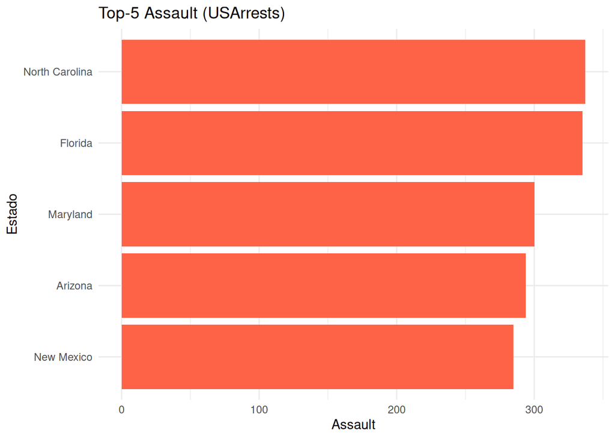

```r
# Barras: top-5 Assault
ua_top5 %>%
  mutate(state = reorder(state, Assault)) %>%
  ggplot(aes(x = state, y = Assault)) +
  geom_col(fill = "tomato") +
  coord_flip() +
  labs(title = "Top-5 Assault (USArrests)",
       x = "Estado", y = "Assault")
```

**Gráfico de barras apiladas**

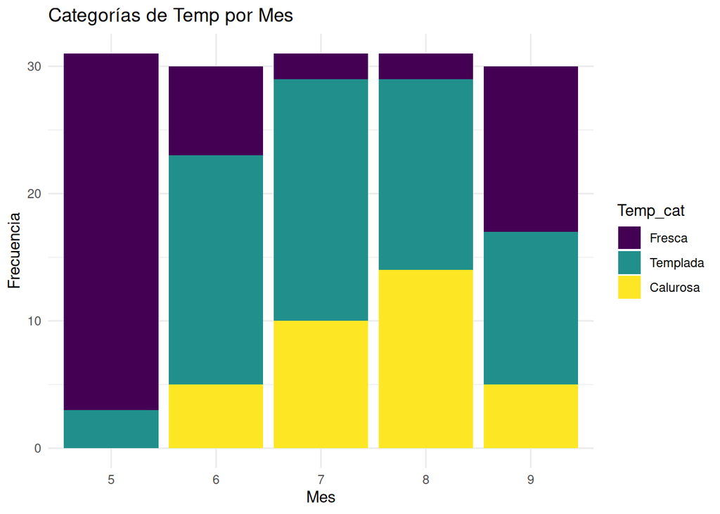

```r
aq2 %>%
  filter(!is.na(Temp_cat)) %>%
  count(Month, Temp_cat) %>%
  ggplot(aes(x = factor(Month), y = n, fill = Temp_cat)) +
  geom_col() +
  labs(title = "Categorías de Temp por Mes",
       x = "Mes", y = "Frecuencia", fill = "Temp_cat")
```

**Gráfico de barras agrupadas**

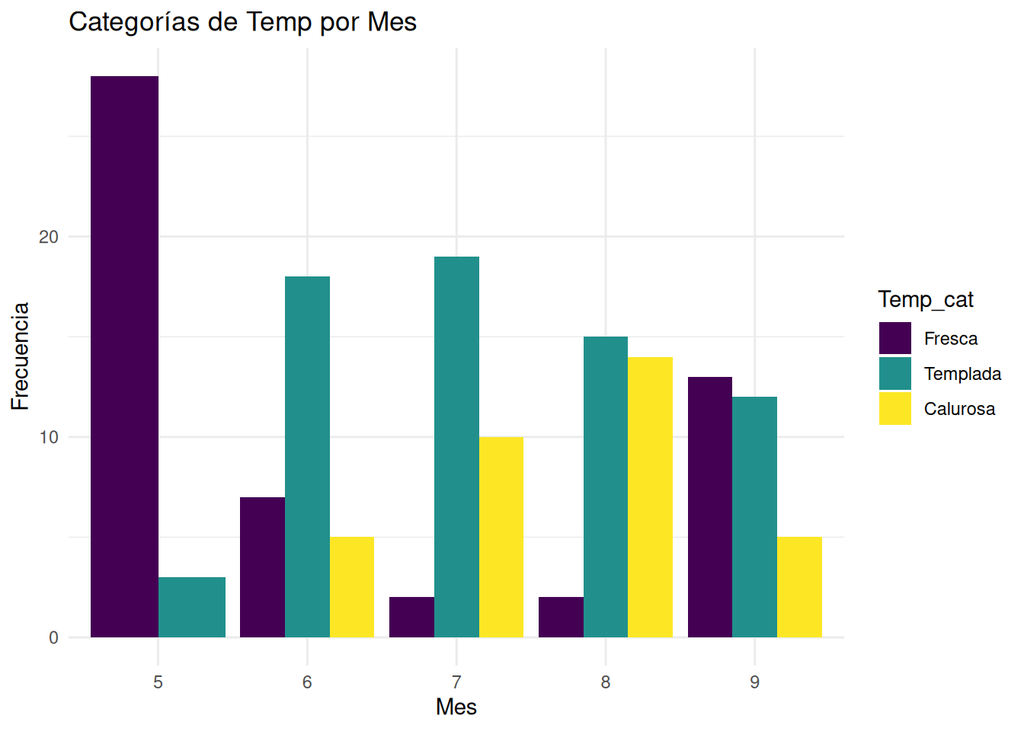

```r
aq2 %>%
  filter(!is.na(Temp_cat)) %>%
  count(Month, Temp_cat) %>%
  ggplot(aes(x = factor(Month), y = n, fill = Temp_cat)) +
  geom_col(position = position_dodge(width = 0.9)) +
  labs(title = "Categorías de Temp por Mes",
       x = "Mes", y = "Frecuencia", fill = "Temp_cat")
```

**Gráfico de dispersión con línea de tendencia**

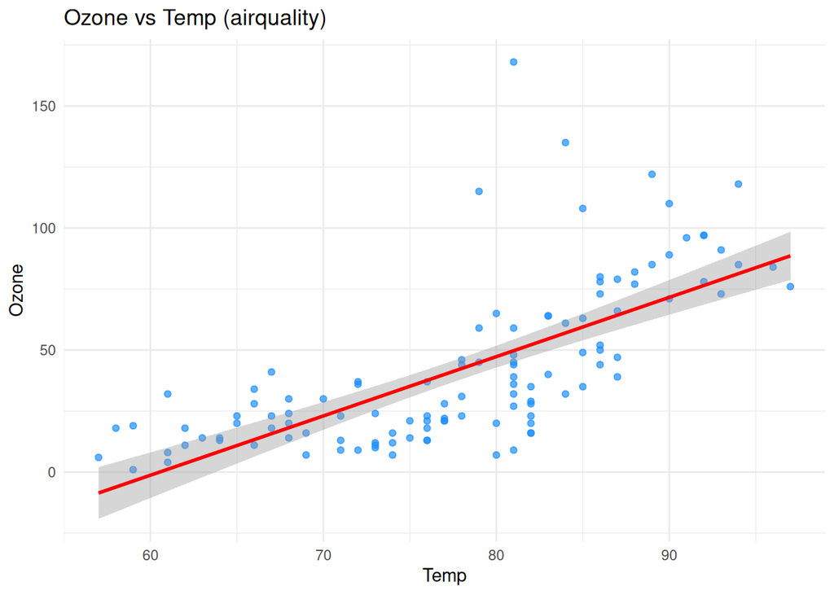

```r
aq %>%
  filter(!is.na(Ozone), !is.na(Temp)) %>%
  ggplot(aes(x = Temp, y = Ozone)) +
  geom_point(alpha = 0.7, color = "dodgerblue") +
  geom_smooth(method = "lm", color = "red") +
  labs(title = "Ozone vs Temp (airquality)",
       x = "Temp", y = "Ozone")
```

**Gráfico de dispersión coloreando por categoría**

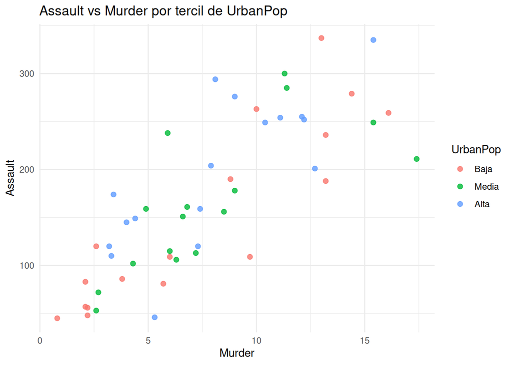

```r
ua2 %>%
  ggplot(aes(x = Murder, y = Assault, color = UrbanCat)) +
  geom_point(size = 2, alpha = 0.8) +
  labs(title = "Assault vs Murder por tercil de UrbanPop",
       x = "Murder", y = "Assault", color = "UrbanPop")
```

**Histograma**

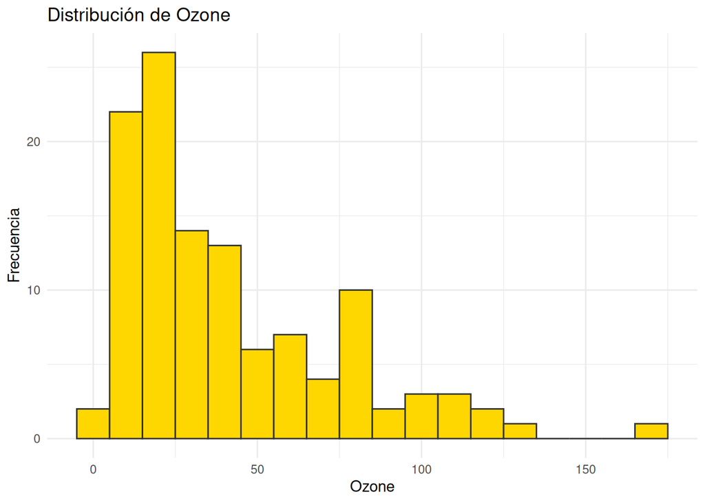

```r
aq %>%
  ggplot(aes(x = Ozone)) +
  geom_histogram(binwidth = 10, fill = "gold", color = "grey20", na.rm = TRUE) +
  labs(title = "Distribución de Ozone", x = "Ozone", y = "Frecuencia")
```

**Histograma por grupos**

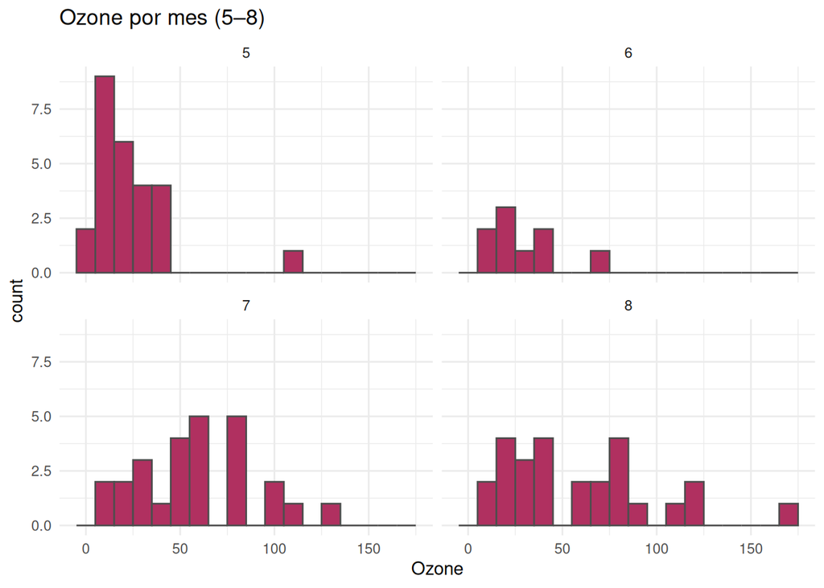

```r
aq %>%
  filter(Month %in% 5:8) %>%
  ggplot(aes(x = Ozone)) +
  geom_histogram(binwidth = 10, fill = "maroon", color = "grey30", na.rm = TRUE) +
  facet_wrap(~ Month, ncol = 2) +
  labs(title = "Ozone por mes (5–8)")
```

**Boxplot**

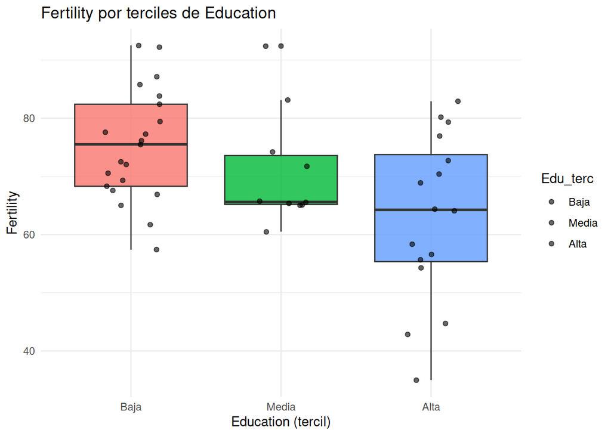

```r
sw2 %>%
  ggplot(aes(x = Edu_terc, y = Fertility, fill = Edu_terc)) +
  geom_boxplot(alpha = 0.8, show.legend = FALSE) +
  geom_jitter(width = 0.2, alpha = 0.6) + # añade los puntitos
  labs(title = "Fertility por terciles de Education",
       x = "Education (tercil)", y = "Fertility")
```

**Serie temporal**

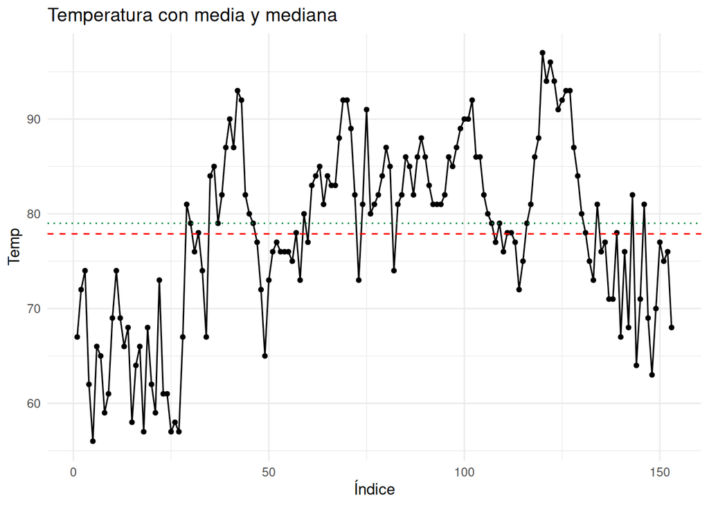

```r
aq %>%
  mutate(idx = row_number()) %>%
  ggplot(aes(x = idx, y = Temp)) +
  geom_line() +
  geom_point(size = 1.2) +
  geom_hline(yintercept = mean(aq$Temp, na.rm = TRUE), linetype = 2, color = "red") +
  geom_hline(yintercept = median(aq$Temp, na.rm = TRUE), linetype = 3, color = "springgreen4") +
  labs(title = "Temperatura con media y mediana",
       x = "Índice", y = "Temp")
```